# Concrete Compressive Strength Report

Andres Gomez

2023-02-11

## Introduction of the Concrete Data Set

Concrete is the most important material in civil engineering. The concrete compressive **strength** is a highly nonlinear function of **age** and ingredients. These ingredients include cement, blast furnace slag, fly ash, water, superplasticizer, coarse aggregate, and fine aggregate.

### Data Description:

#### Variables:

- **cem** : Cement
- **slag**: Blast Furnace Slag
- **FA**: Fly Ash
- **h2o**: Water
- **plast**: Superplasticizer
- **cAgg**: Coarse Aggregate
- **fAgg**: Fine Aggregate

The following table represents the first 10 rows found in the **Concrete Data Set**:

```
## # A tibble: 10 × 8
##    Cement Furnace_Slag Fly_Ash Water Superplasticizer CoarsAgg FineAgg Strength
##     <dbl>        <dbl>   <dbl> <dbl>            <dbl>    <dbl>   <dbl>    <dbl>
##  1   199.         132.       0   192              0       978.    826.     44.3
##  2   266          114        0   228              0       932     670      47.0
##  3   266          114        0   228              0       932     670      45.8
##  4   332.         142.       0   228              0       932     594      40.3
##  5   332.         142.       0   228              0       932     594      41.0
##  6   380           95        0   228              0       932     594      43.7
##  7   380           95        0   228              0       932     594      36.4
##  8   475            0        0   228              0       932     594      39.3
##  9   540            0        0   162              2.5    1040     676      80.0
## 10   540            0        0   162              2.5    1055     676      61.9
```

Note that the data above is grouped by ingredients with the **strength** variable as a result.

### Simple Linear Regression (SLR):

#### Pairs plot:

The following graph is known as a pairs plot which will be useful to further understand the data that will be used throughout the report.

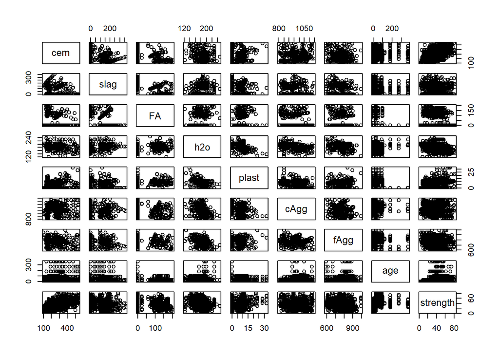